# Association testing in R

Jazmin MM ft datatrail

2024-08-05

## 0.1 Can we infer the height of a tree given its girth?

For this example we’ll use the trees dataset available in R, which includes girth, height, and volume measurements for 31 black cherry trees.

Presumably, it’s easier to measure a trees girth (width around) than it is to measure its height. Thus, here we want to know whether or not height and girth are associated.

First, before carrying out the linear regression to test for association and answer this question, we have to be sure linear regression is appropriate. We’ll test for linearity and homoscedasticity.

To do so, we’ll first use ggplot2 to generate a scatterplot of the variables of interest.

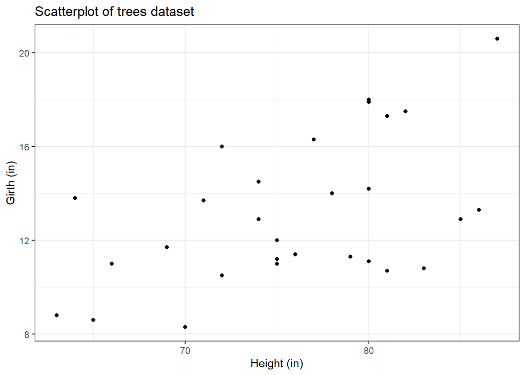

```r
library(ggplot2)

ggplot(trees) +
  geom_point(aes(Height, Girth)) +
  labs(title = "Scatterplot of trees dataset", x = "Height (in)", y = "Girth (in)") +
  theme_bw()
```

From the looks of this plot, the relationship looks approximately linear, but to visually make this a little easier, we’ll add a line of best first to the plot.

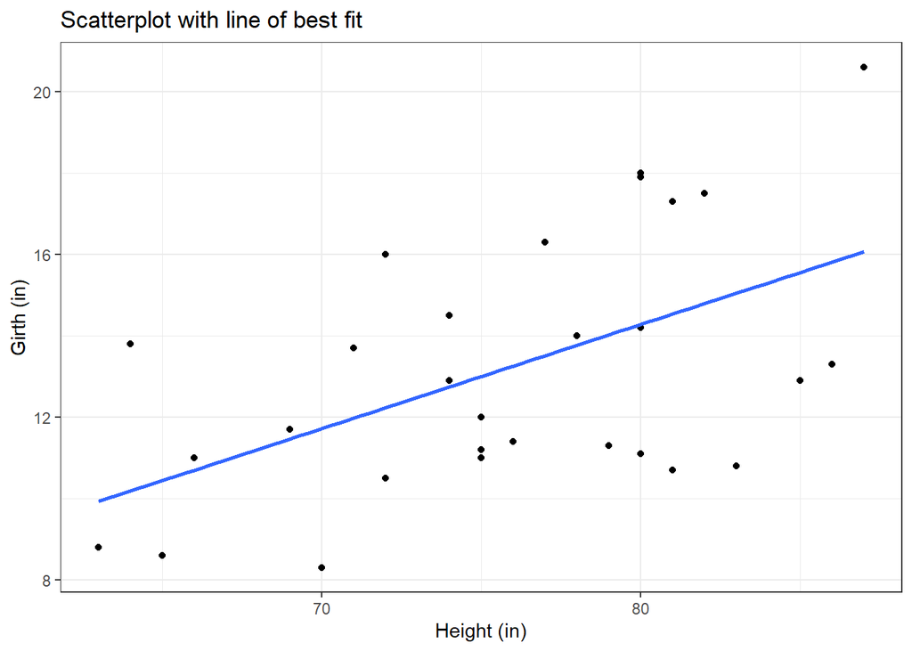

```r
ggplot(trees, aes(Height, Girth)) +
  geom_point() +
  geom_smooth(method = "lm", se = FALSE) +
  labs(title = "Scatterplot with line of best fit",  x = "Height (in)", y = "Girth (in)") +
  theme_bw()
```

## 0.2 Fitting the model

On this graph, the relationship looks approximately linear and the variance (distance from points to the line) is constant across the data. Given this, it’s appropriate to use linear regression for these data.

```r
## run the regression
fit <- lm(Girth ~ Height , data = trees)
```

A histogram (or densityplot) is a great way to see the shape of your data when you are first getting acquainted with it. This can tell you whether or not your data truly looks normally distributed or not. If your data is not normally distributed, it won’t be appropriate to use linear regression.

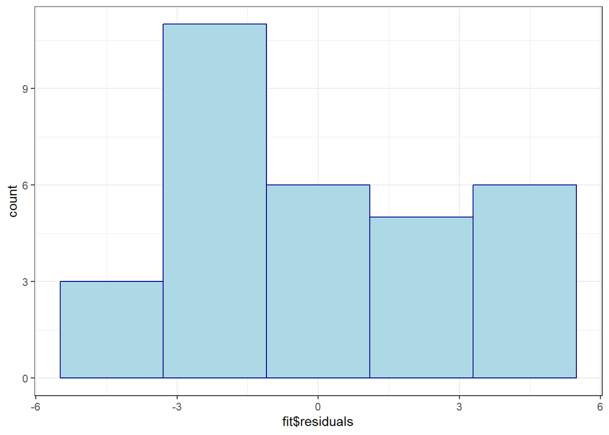

```r
library(ggplot2)
ggplot(fit, aes(fit$residuals)) +
  geom_histogram(bins = 5, color="darkblue", fill="lightblue") +
  theme_bw()
```

## 0.3 Interpreting the model

```r
## take a look at the output
summary(fit)
```

```
##
## Call:
## lm(formula = Girth ~ Height, data = trees)
##
## Residuals:
##     Min      1Q  Median      3Q     Max
## -4.2386 -1.9205 -0.0714  2.7450  4.5384
##
## Coefficients:
##             Estimate Std. Error t value Pr(>|t|)
## (Intercept) -6.18839    5.96020  -1.038  0.30772
## Height       0.25575    0.07816   3.272  0.00276 **
## ---
## Signif. codes:  0 '***' 0.001 '**' 0.01 '*' 0.05 '.' 0.1 ' ' 1
##
## Residual standard error: 2.728 on 29 degrees of freedom
## Multiple R-squared:  0.2697, Adjusted R-squared:  0.2445
## F-statistic: 10.71 on 1 and 29 DF,  p-value: 0.002758
```

The summary() function summarizes the model as well as the output of the model. We can see the values we’re interested in in this summary, including the beta estimate, the standard error (SE), and the p-value.

## 0.4 Using `broom

The tidy() function from the broom package helps take the summary output from a statistical model and organize it into a tabular output.

```r
#install.packages("broom")
library(broom)

tidy(fit)
```

```
## # A tibble: 2 × 5
##   term        estimate std.error statistic p.value
##   <chr>          <dbl>     <dbl>     <dbl>   <dbl>
## 1 (Intercept)   -6.19     5.96       -1.04 0.308
## 2 Height         0.256    0.0782      3.27 0.00276
```

Note that the values haven’t changed. They’re just organized into an easy-to-use table. It’s helpful to keep in mind that this function and package exist as you work with statistical models.

Finally, it’s important to always keep in mind that the **interpretation of your inferential data analysis** is incredibly important. When you use linear regression to test for association, you’re looking at the relationship between the two variables. While girth can be used to infer a tree’s height, this is just a correlation. It **does not mean** that an increase in girth causes the tree to grow more. Associations are correlations. They are **not causal**. We’ll discuss this more later in the lesson.